# Biol/Math 218 Portfolio 2

Data manipulation and basic plotting

## Introduction

In this portfolio, you will demonstrate your skills at uploading data and doing basic data exploration and plotting. Answers to each **question** should be entered in the designated `Answer:` block. All **exercises** need to be done within `r{}` chunks, with any non-code commented out with **#**.

## Part 01: Dealing with data

### Exercise 01

In the space below, write a `r{}` code chunk to

1. Call the “iris” data set, without the whole data set being printed
2. List the column names of the data set
3. Determine which columns are numeric and which are factors
4. Determine the levels of the factors

### Exercise 02

In the space below, write a `r{}` code chunk to:

1. Export the `iris` data set as a *.csv file
2. Import that *.csv as a data frame called “iris_import”
3. Create a vector of only petal width observations
4. Create a separate data frame of only the *Iris setosa* observations
5. Create a separate vector of only *Iris veriscolor* sepal lengths

## Part 02: Basic plotting

**Question 01**: What are the four rules for drawing a good graph?

### Exercise 03-01

Run the following code to produce a bar graph

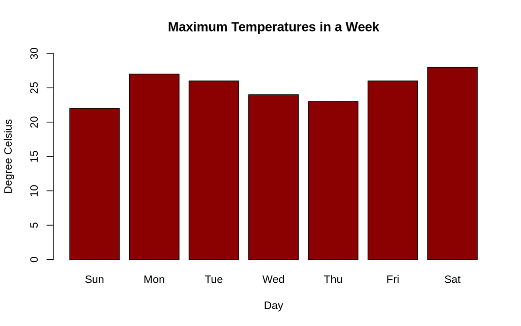

```r
max_temp <- c(22, 27, 26, 24, 23, 26, 28)

## Barplot() function
barplot(max_temp,
        main = "Maximum Temperatures in a Week",
        ylab = "Degree Celsius",
        xlab = "Day",
        ylim = c(0, 30),
        names.arg = c("Sun", "Mon", "Tue", "Wed", "Thu", "Fri", "Sat"),
        col = "darkred",
        horiz = FALSE)
```

**Question 02**: For what sort of data are bar graphs used?

**Question 03**: Which day had the highest maximum temperature during that week?

### Exercise 03-02

In a new `r{}` code chunk below, recreate this bar graph for the following temperatures: 31, 27, 24, 23, 25, 28, 22 and make the bars **light blue**

*Hint: Use copy/paste and make sure to change the ylim() to an appropriate range*

### Exercise 04-01

Run the following code to plot a scatter plot of *Iris* petal width and petal length

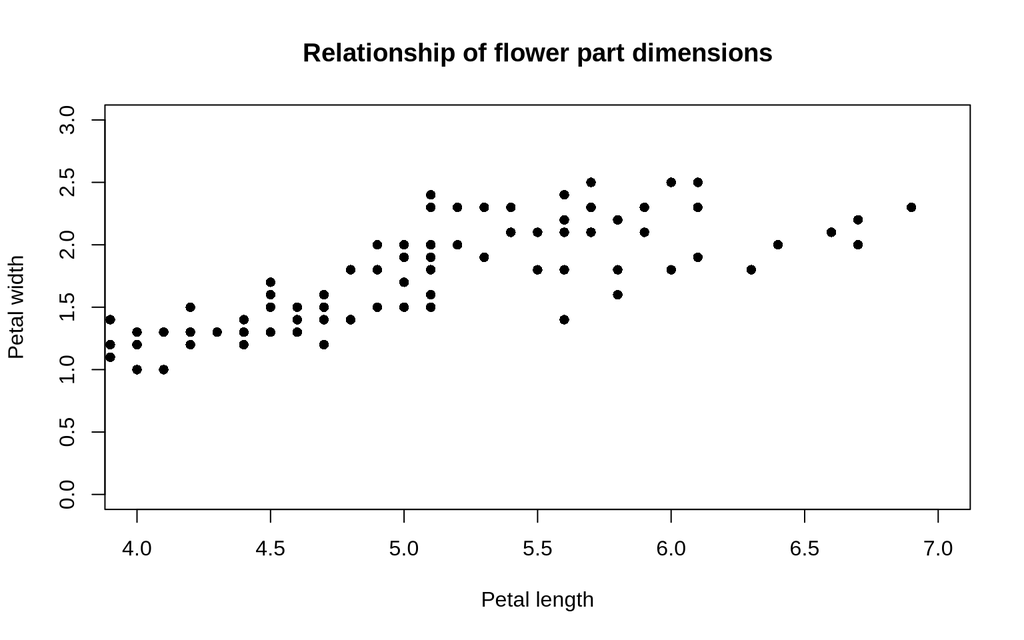

```r
data(iris)

plot(iris$Petal.Length, iris$Petal.Width, pch = 16, col = "black",
     main = "Relationship of flower part dimensions", xlab = "Petal length",
     ylab = "Petal width",
     xlim = c(4, 7), ylim = c(0, 3))
```

**Question 04**: What is the relationship between petal length and petal width?

### Exercise 04-02

To look at the strength of the relationship, you can plot the line of best fit by using the lm() and abline() functions. Practice that here, but we will look into this in more depth later on in the semester.

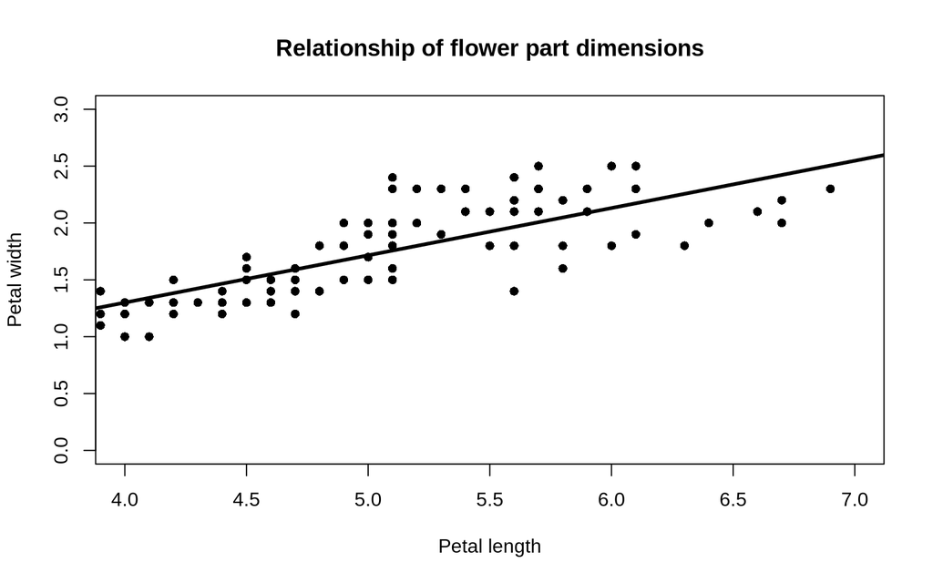

```r
data(iris)

plot(iris$Petal.Length, iris$Petal.Width, pch = 16, col = "black",
     main = "Relationship of flower part dimensions", xlab = "Petal length",
     ylab = "Petal width",
     xlim = c(4, 7), ylim = c(0, 3))

bestfit <- lm(iris$Petal.Width ~ iris$Petal.Length) # Form y ~ x
abline(bestfit, lwd = 3) # lwd: line width
```

### Exercise 04-03

Recreate this plot and line of best fit for the sepal length and sepal widths of *Iris* in a code chunk below. Change colors if you would like, but make sure to change the x and y limits if needed

### Exercise 05

Run this box and whisker plot and answer the question.

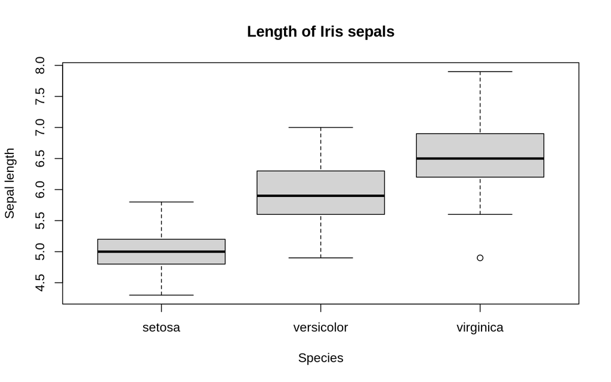

```r
data(iris)

boxplot(iris$Sepal.Length ~ iris$Species,
      main = "Length of Iris sepals",
      ylab = "Sepal length",
      xlab = "Species")
```

**Question 05**: What do the thick lines in the boxes represent? What do the whiskers represent?

### Exercise 06

Run this violin plot and answer the question.

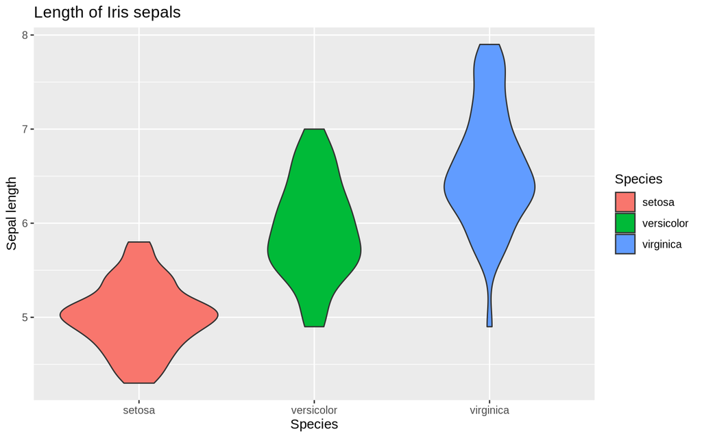

```r
data(iris)
library(ggplot2)

ggplot(iris, aes(x = Species, y = Sepal.Length, fill = Species)) +
  ggtitle("Length of Iris sepals") +
  xlab("Species") +
  ylab("Sepal length") +
  geom_violin()
```

**Question 06**: Why is this called a violin plot? What do they represent?

## Part 3: Advanced plots

### Exercise 07

Go to https://r-graph-gallery.com/ and:

1. Choose two plot types that we have not gone over here
2. Copy and paste code to produce each plot in their own chunk, making sure that they work properly